# Introduction

In this work we will analyse a photos from the chamber of representatives. The aim of this work is demonstrate the use of scikit in python using an eigenfaces exercise. First will construct a class for storing the information of the chamber of representatives. Later we will import the image dataset, compute some descriptive statistics, perform an analysis of principal components, clustering analysis and finally will use a non-linear classifier to assess the gender from just the image of the representative.

## Diputado Class

A diputado has a Name, Surnames, ID, Picture, Gender and Political Affiliation

```python
%pylab inline
class Diputado(object):
    def __init__(self,ind,fileRoot="./"):
        self.name=""
        self.surname=""
        self.ind=ind
        self.picfile=""
        self.party=""
        self.gender=""
        self.fileRoot=fileRoot
        self.ext="c.jpg"
    def setName(self,name):
        self.name=name
    def setSurname(self,surname):
        self.surname=surname
    def setParty(self,party):
        self.party=party
    def setGender(self,gender):
        self.gender=gender
    def getName(self):
        return self.name
    def getSurname(self):
        return self.surname
    def getInd(self):
        return self.ind
    def getPicfile(self):
        return self.fileRoot + str(self.ind) + self.ext
    def getParty(self):
        return self.party
    def getGender(self):
        return self.gender
```

## Parlament class

Let's define a very simple Parlament object, where we store the diputados objects. From this class, we have to be able to get information from the parlament.

```python
%pylab inline
class Class_obj(object):
    def __init__(self,ind,fileRoot="./"):
        self.name=""
        self.surname=""
        self.ind=ind
        self.picfile=""
        self.party=""
        self.gender=""
        self.fileRoot=fileRoot
        self.ext="c.jpg"
    def setName(self,name):
        self.name=name
    def setSurname(self,surname):
        self.surname=surname
    def setParty(self,party):
        self.party=party
    def setGender(self,gender):
        self.gender=gender
    def getName(self):
        return self.name
    def getSurname(self):
        return self.surname
    def getInd(self):
        return self.ind
    def getPicfile(self):
        return self.fileRoot + str(self.ind) + self.ext
    def getParty(self):
        return self.party
    def getGender(self):
        return self.gender
```

```python
class Parlament(object):
    def __init__(self):
        self.elements=[]
        self.inds=[]
        self.ndips=0
    def add(self, diputado):
        self.elements.append(diputado)
        self.inds.append(diputado.getInd())
        self.ndips +=1
    def getInds(self):
        return [self.elements[i].getInd() for i in range(self.ndips)]
    def len(self):
        return len(self.elements)
    def __getitem__(self, key):
        if isinstance(key, slice):
            indices = key.indices(self.ndips)
            return [self[ii] for ii in xrange(*key.indices(self.len()))]
        else:
            return self.elements[key]
    def getName(self,key):
        return self.elements[key].getName()
```

```python
import csv
with open('db/index.csv','r') as csvfile:
    r = csv.reader(csvfile, delimiter=';')
    r.__next__()
    p = Parlament()
    for row in r:
        n = Diputado(int(row[0]),"db/db/")
        n.setName(row[1].strip())
        n.setSurname(row[2].strip())
        n.setGender(row[3].strip())
        n.setParty(row[4].strip())
        p.add(n)
```

```python
p.len()
p[99].getPicfile()
```

```
'db/db/91c.jpg'
```

Let's create a dataset of the analysis.

```
'Joaquín|Leguina Herrán|H'
```

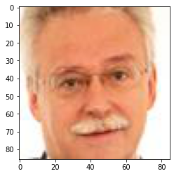

```python
from scipy import ndimage,misc
import numpy as np
import matplotlib.pyplot as pl
idip = 122
I = pl.imread(p[idip].getPicfile())
pl.imshow(I)
np.shape(I)
'|'.join([p[idip].getName(), p[idip].getSurname(), p[idip].getGender()])
```

```python
shape(I)
```

[output not shown]

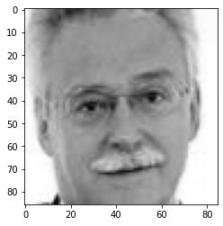

```python
I = pl.imread(p[idip].getPicfile()).mean(axis=2)
img=pl.imshow(I)
img.set_cmap('gray')

Is=shape(I)
```

```python
Is
```

```
(86, 85)
```

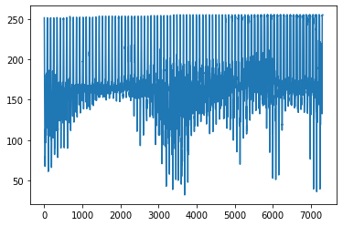

```python
Iv = np.reshape(I,np.prod(Is))
pl.plot(Iv)
```

Let's stack all images to an array and create a couple of dependent variables.

```python
X=np.array([ pl.imread(d.getPicfile()).mean(axis=2).ravel()
             for d in p])
shape(X)
Yg=np.array([ d.getGender() for d in p])
Yp=np.array([ d.getParty() for d in p])
Yp[0:5],Yg[0:5],shape(X)
```

```
(array(['GS', 'GS', 'GC-CiU', 'GP', 'GP'], dtype='<U10'),
 array(['H', 'M', 'H', 'H', 'H'], dtype='<U1'),
 (348, 7310))
```

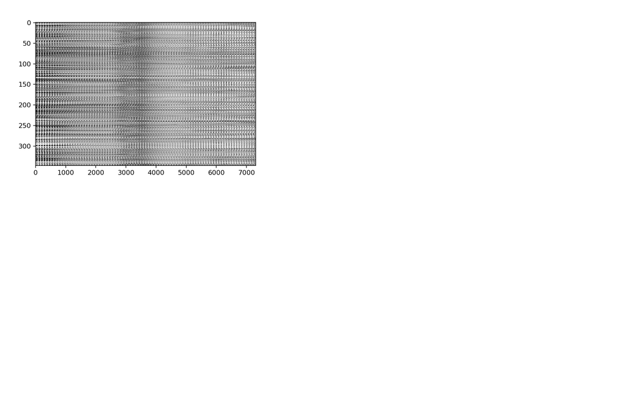

```python
%pylab notebook
pl.imshow(X,aspect='auto')
pl.set_cmap('gray')
```

# 1 - Compute the mean representative and plot the corresponding image

```python
mX = X.mean(axis = 0)
mX.shape
```

```
(7310,)
```

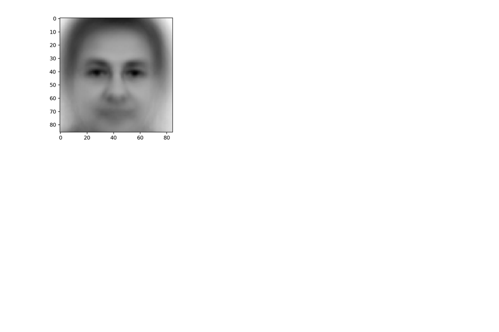

```python
pl.figure()
pl.imshow(mX.reshape(Is))
```

Is interesting observe how the mean face of the data remember a male face. There are more mens than womens in the chamber and for this reason the mean face is more likely a men face.

```python
unique_elements, counts_elements = np.unique(Yg, return_counts=True)

print(unique_elements[1], '|', counts_elements[1], '|', round(counts_elements[1]/348*100),'%')
print(unique_elements[0], '|', counts_elements[0], '|', round(counts_elements[0]/348*100),'%')
```

```
M | 125 | 36 %
H | 223 | 64 %
```

# 2 - Compute the standard deviation and plot the corresponding image

```python
sX = X.std(axis=0)
sX.shape
```

```
(7310,)
```

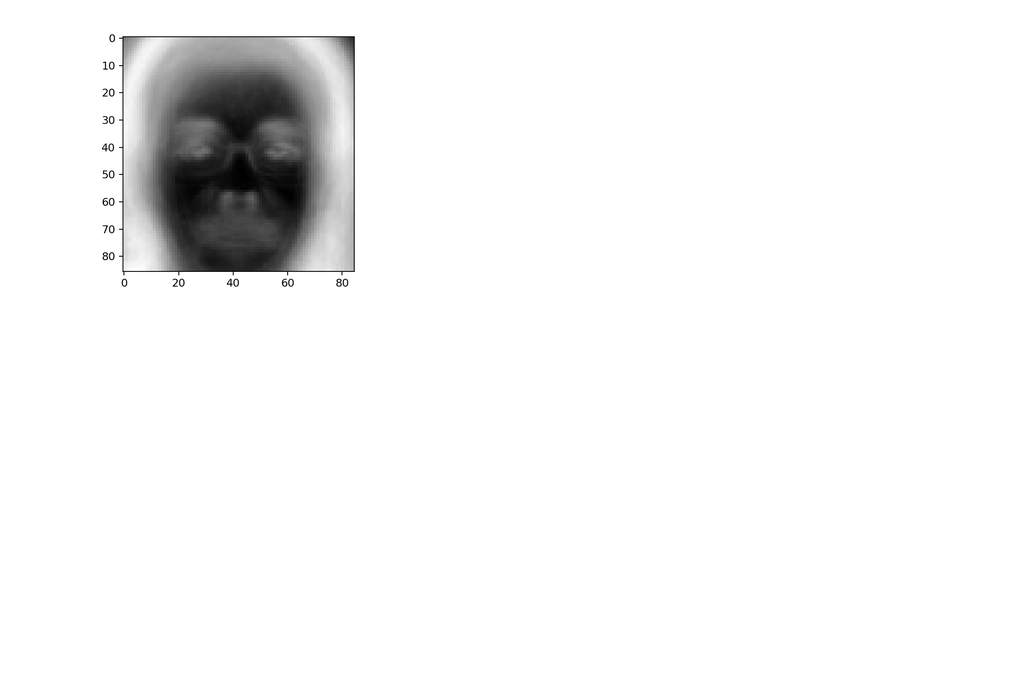

```python
pl.figure()
pl.imshow(sX.reshape(Is))
```

# 3 - Run a k-means clustering and split the representatives' data into 10 groups. Plot the full set of images for two groups of your choice

In this section is done a KMeans for clustering in two type the image data-set.

The result of the class 1 of this clustering is showed below.

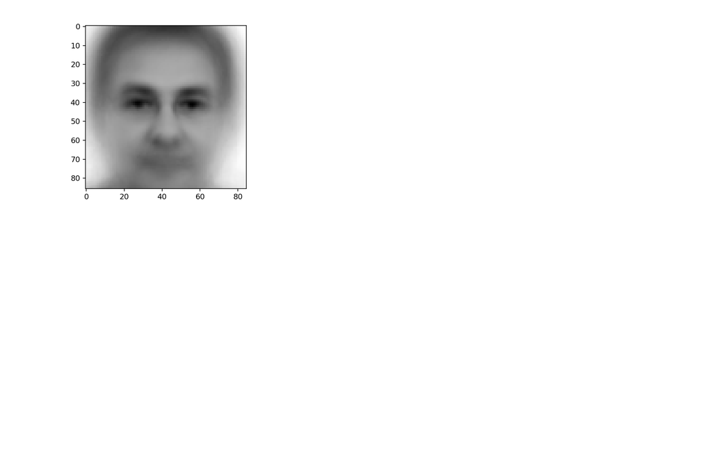

```python
from sklearn import cluster
seed = 123
k_means = cluster.KMeans(n_clusters = 2, random_state = seed)
k_means.fit(X)
pl.figure()
pl.imshow(  k_means.cluster_centers_[0,:].reshape(Is)  )
```

Below is showed the second type classification by KMeans.

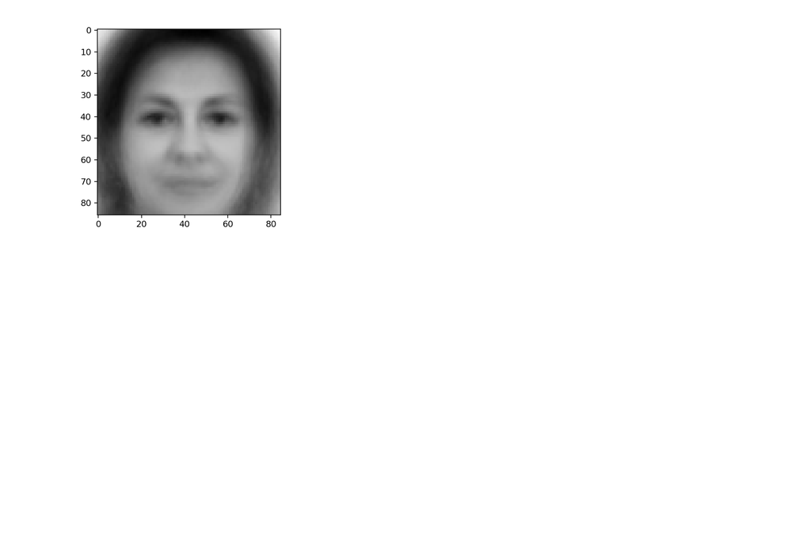

```python
pl.figure()
pl.imshow(  k_means.cluster_centers_[1,:].reshape(Is)  )
```

Now, we going to cointinue our analysis doing it for 10 groups.

```python
from sklearn import cluster
seed = 123
k_means = cluster.KMeans(n_clusters = 10,  random_state = seed)
k_means.fit(X)
```

```
KMeans(n_clusters=10, random_state=123)
```

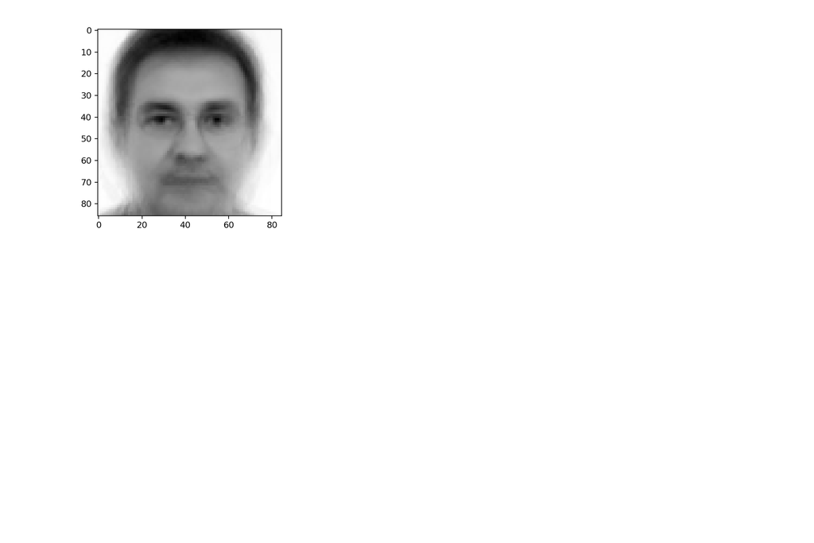

```python
pl.figure()
pl.imshow(  k_means.cluster_centers_[0,:].reshape(Is)  )
```

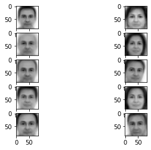

```python
%matplotlib inline

f, axarr = plt.subplots(5,2)
axarr[0,0].imshow(k_means.cluster_centers_[ 0,:].reshape(Is))
axarr[1,0].imshow(k_means.cluster_centers_[ 6,:].reshape(Is))
axarr[2,0].imshow(k_means.cluster_centers_[ 2,:].reshape(Is))
axarr[3,0].imshow(k_means.cluster_centers_[ 8,:].reshape(Is))
axarr[4,0].imshow(k_means.cluster_centers_[ 9,:].reshape(Is))

axarr[0,1].imshow(k_means.cluster_centers_[ 1,:].reshape(Is))
axarr[1,1].imshow(k_means.cluster_centers_[ 5,:].reshape(Is))
axarr[2,1].imshow(k_means.cluster_centers_[ 7,:].reshape(Is))
axarr[3,1].imshow(k_means.cluster_centers_[ 3,:].reshape(Is))
axarr[4,1].imshow(k_means.cluster_centers_[ 4,:].reshape(Is))
```

# 4 - Plot the centroid corresponding to each k-means cluster (10 images corresponding to the mean of each cluster)

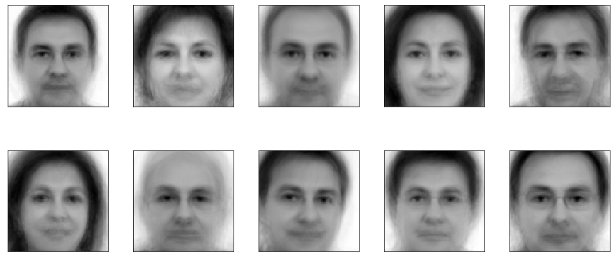

```python
from matplotlib import pyplot as plt
fig = plt.figure(figsize=(12, 11))
fig.subplots_adjust(left=0, right=1, bottom=0, top=1, hspace=0.25, wspace=0.25)

for i in range(10):
    ax = fig.add_subplot(4, 5, i + 1, xticks=[], yticks=[])
    ax.imshow(k_means.cluster_centers_[i].reshape(86,85),  interpolation='nearest')
```

# 5 - Fit a PCA model of the dataset.

```python
from sklearn.decomposition import PCA
from sklearn import preprocessing

sX = preprocessing.scale(X) # we scale our data N(0,1)


model_PCA = PCA( n_components = 5 )
model_PCA.fit(sX)
# model_PCA.explained_variance
```

```
PCA(n_components=5)
```

```python
model_PCA.explained_variance_ratio_ # var explained by each component
```

```
array([0.2136283 , 0.08746378, 0.07299065, 0.0517424 , 0.04674383])
```

```python
model_PCA.explained_variance_ratio_.cumsum()
```

```
array([0.2136283 , 0.30109208, 0.37408273, 0.42582514, 0.47256897])
```

```python
T = model_PCA.transform(sX) # with this we could use for new data
```

```python
T.shape   # 5 col because we compute 5 components
```

```
(348, 5)
```

# 6 - Build a 2D score plot with the projections of the representatives onto the PCA plane

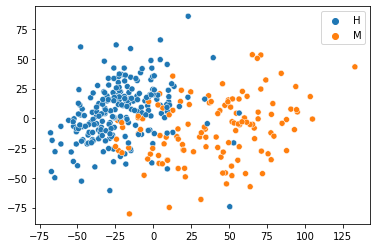

```python
pl.figure()
import seaborn as sns
sns.scatterplot(T[:,0], T[:,1], hue = Yg)
```

# 7 - Plot the first three eigenvectors projection vectors

```python
model_PCA.components_.shape
```

```
(5, 7310)
```

```python
model_PCA.components_.reshape( (5, Is[0], Is[1]) ).shape
```

```
(5, 86, 85)
```

```python
# Plot the images
e = model_PCA.components_.reshape( (5, Is[0], Is[1]) )
```

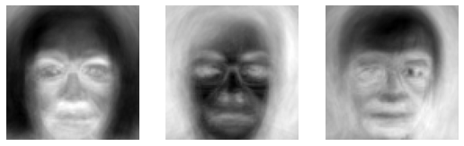

```python
pl.figure(figsize = (9,3))
pl.subplot(131)
pl.imshow(e[0])
pl.axis('off')

pl.subplot(132)
pl.imshow(e[1])
pl.axis('off')

pl.subplot(133)
pl.imshow(e[2])
pl.axis('off')

#plt.subplot_adjust(wspace = 0.01, hspace = 0.01,
#                top = 1, bottom = 0, left = 0,
#                  right = 1)
pl.show()
```

# 8 - Plot the amount of variance explained by each PCs

```python
from tabulate import tabulate

var_explain = model_PCA.explained_variance_ratio_   # % explained by each PC
table = [ ['1st PC', model_PCA.explained_variance_ratio_[0]*100],
          ['2nd PC', model_PCA.explained_variance_ratio_[1]*100],
          ['3rd PC', model_PCA.explained_variance_ratio_[2]*100],
          ['4th PC', model_PCA.explained_variance_ratio_[3]*100],
          ['5th PC', model_PCA.explained_variance_ratio_[4]*100] ]

print(tabulate(table))
```

```
------  --------
1st PC  21.3628
2nd PC   8.74638
3rd PC   7.29907
4th PC   5.17424
5th PC   4.67438
------  --------
```

# 9 - Train a gender predictor with the class of representatives. Which performance can you get on predicting gender from the images? Provide metrics

First of all, we going to split the data into a train and test subset. This is done in order to do not overfitting the data.

- **Split the data**

```python
from sklearn.model_selection import train_test_split
seed = (123)
x_train, x_test, y_train, y_test = train_test_split(sX, Yg, random_state = seed)
```

```python
shape(x_train[0,:])
```

```
(7310,)
```

```python
shape(sX[0,:])
```

```
(7310,)
```

- **Support Vector Classifier**

```python
from sklearn.svm import SVC

#Support Vector Classifier
s_clf = SVC()
s_clf.fit(x_train, y_train)
s_prediction = s_clf.predict(x_test)
```

```python
import numpy as np
from sklearn.metrics import accuracy_score

#accuracy scores
s_acc_SVM = accuracy_score(s_prediction,y_test)
print(s_acc_SVM)
```

```
0.9080459770114943
```

Check if changing the kernel we get a better performance

```python
from sklearn.metrics import confusion_matrix
from sklearn.model_selection import train_test_split
from sklearn import svm, datasets
import matplotlib.pyplot as plt
import numpy as np
```

```python
# try the best kernel:

linear_g = svm.SVC(kernel='linear', C=1, decision_function_shape='ovo').fit( x_train, y_train )
rbf_g = svm.SVC(kernel='rbf', gamma=1, C=1, decision_function_shape='ovo').fit( x_train, y_train )
poly_g = svm.SVC(kernel='poly', degree=3, C=1, decision_function_shape='ovo').fit( x_train, y_train )
sig_g = svm.SVC(kernel='sigmoid', C=1, decision_function_shape='ovo').fit( x_train, y_train )
```

```python
linear_pred_g = linear_g.predict( x_test )
poly_pred_g = poly_g.predict( x_test )
rbf_pred_g = rbf_g.predict( x_test )
sig_pred_g = sig_g.predict( x_test )
```

```python
# retrieve the accuracy and print it for all 4 kernel functions
accuracy_lin_g = linear_g.score( x_test, y_test )
accuracy_poly_g = poly_g.score( x_test, y_test )
accuracy_rbf_g = rbf_g.score( x_test, y_test )
accuracy_sig_g = sig_g.score( x_test, y_test )

print('Kernel sigma:',round(100*accuracy_sig_g),'%') # same as we did with SVC
print('Kernel RBF:',round(accuracy_rbf_g*100), '%')
print('Kernel Poly:', round(accuracy_poly_g*100),'%')
print('Kernel lineal:', round(accuracy_lin_g*100),'%')
```

```
Kernel sigma: 94 %
Kernel RBF: 64 %
Kernel Poly: 82 %
Kernel lineal: 90 %
```

- **Decision tree classifier**

```python
from sklearn import tree

# Decision Tree
dtc_clf = tree.DecisionTreeClassifier()
dtc_clf = dtc_clf.fit( x_train, y_train )
dtc_prediction = dtc_clf.predict( x_test )
```

```python
# Accuracy score
s_acc_DT = accuracy_score( dtc_prediction, y_test )
print(s_acc_DT)
```

```
0.8275862068965517
```

- **Random forest**

```python
from sklearn.ensemble import RandomForestClassifier

# Random Forest
rfc_clf = RandomForestClassifier()
rfc_clf.fit( x_train, y_train )
rfc_prediction = rfc_clf.predict( x_test )
```

```python
# Accuracy score
s_acc_RF = accuracy_score( rfc_prediction, y_test )
print(s_acc_RF)
```

```
0.9080459770114943
```

- **Logistic regression**

```python
from sklearn.linear_model import LogisticRegression

# Logistic Regression
lr_clf = LogisticRegression()
lr_clf.fit( x_train, y_train )
lr_prediction = lr_clf.predict( x_test )
```

```python
# Accuracy score
s_acc_LR = accuracy_score( lr_prediction, y_test )
print(s_acc_LR)
```

```
0.9195402298850575
```

- **Model comparation**

```python
classifiers = ['Decision Tree', 'Random Forest', 'Logistic Regression' , 'SVC']
accuracy = np.array([ s_acc_DT, s_acc_RF, s_acc_LR, s_acc_SVM ])
max_acc = np.argmax(accuracy)
print(classifiers[max_acc] +  ' is the best classifier for this problem')
```

```
Logistic Regression is the best classifier for this problem
```

```python
from tabulate import tabulate

table = [ [1, 'SVM - sigma', (100*accuracy_sig_g) ],
          [2, 'Logistic Regression', s_acc_LR*100],
          [3, 'SVC', s_acc_SVM*100],
          [4, 'Random Forest', s_acc_RF*100],
          [5, 'Decision Tree', s_acc_DT*100] ]

print(tabulate(table))
```

```
-  -------------------  -------
1  SVM - sigma          94.2529
2  Logistic Regression  91.954
3  SVC                  90.8046
4  Random Forest        90.8046
5  Decision Tree        82.7586
-  -------------------  -------
```

As we can see the four models perform really good the data, classify good almost all at 90 %. So there are differences between the women and male images and the model can recognize it.

# 10 - Do the same with the label containing political party of the representatives. Discuss the results

```python
from sklearn.model_selection import train_test_split

x_train_p, x_test_p, y_train_p, y_test_p = train_test_split(sX, Yp, test_size=0.3, random_state = 2)
```

```python
# Let's try with the model with a random forest model

from sklearn.ensemble import RandomForestClassifier

# Random Forest
rfc_party = RandomForestClassifier()
rfc_party.fit( x_train_p, y_train_p )
rfc_party_prediction_p = rfc_party.predict( x_test_p )

# Accuracy score
s_acc_RF = accuracy_score( rfc_party_prediction_p, y_test_p )
print(s_acc_RF)
```

```
0.580952380952381
```

```python
from sklearn.svm import SVC

#Support Vector Classifier
s_clf_p = SVC()
s_clf_p.fit( x_train_p, y_train_p )
s_p_prediction = s_clf_p.predict(x_test_p)

s_acc_SV_p = accuracy_score( s_p_prediction, y_test_p )
print(s_acc_SV_p)
```

```
0.5714285714285714
```

The problem with the models that we used before is that the previuos models class in 2 labels, not multiple labeling

- **First, let's try a SVM multiclass:**

```python
from sklearn.metrics import confusion_matrix
from sklearn.model_selection import train_test_split
from sklearn import svm, datasets
import matplotlib.pyplot as plt
import numpy as np
```

```python
# try the best kernel:

linear = svm.SVC(kernel='linear', C=1, decision_function_shape='ovo').fit( x_train_p, y_train_p )
rbf = svm.SVC(kernel='rbf', gamma=1, C=1, decision_function_shape='ovo').fit( x_train_p, y_train_p )
poly = svm.SVC(kernel='poly', degree=3, C=1, decision_function_shape='ovo').fit( x_train_p, y_train_p )
sig = svm.SVC(kernel='sigmoid', C=1, decision_function_shape='ovo').fit( x_train_p, y_train_p )
```

```python
linear_pred = linear.predict(x_test_p)
poly_pred = poly.predict(x_test_p)
rbf_pred = rbf.predict(x_test_p)
sig_pred = sig.predict(x_test_p)
```

```python
# retrieve the accuracy and print it for all 4 kernel functions
accuracy_lin = linear.score(x_test_p, y_test_p)
accuracy_poly = poly.score(x_test_p, y_test_p)
accuracy_rbf = rbf.score(x_test_p, y_test_p)
accuracy_sig = sig.score(x_test_p, y_test_p)

print('Kernel sigma:',round(100*accuracy_sig),'%')
print('Kernel RBF:',round(accuracy_rbf*100), '%')
print('Kernel Poly:', round(accuracy_poly*100),'%')
print('Kernel lineal:', round(accuracy_lin*100),'%')
```

```
Kernel sigma: 52 %
Kernel RBF: 49 %
Kernel Poly: 56 %
Kernel lineal: 50 %
```

# Results

As expected the results show how almost half the times the models will classify bad the party of each face. We can expect that because else will mean that people have a specific face if they are from one party and you could recognize the party of a person only seen their face.

As we can see the results of SVM are not so good. We should try another model. I tried to perform a NN multilabel classifier, but unfurtonetly didn't work propertly and is not included in this work.

# Bonus questions:

# 1 - Use the model you have built in 9 to predict the gender of your fellow class. Discuss the results

# Import class images

In order to import class images we should create a new import function, because the images are stored in diferents files and the format is not the same as before.

**We delete the image 'Photo_Gaëlle_MUGNIER.ipynb' because it is not in the correct format**

Create a function that read all images in a file:

```python
import cv2
import os

def load_images(folder):
    images = []
    for filename in os.listdir(folder):
        img = pl.imread(os.path.join(folder, filename))
        if img is not None:
            images.append(img)
    return(images)
```

We create an array with all file names in the directory './classdb'

```python
folder = './classdb'

sub_folders = [name for name in os.listdir(folder) if os.path.isdir(os.path.join(folder, name))]

n_folder = np.array(sub_folders)
```

Now, we do a loop in order to store all the images on an array

```python
list_ = []
for i in range(len(n_folder)):
    folder = '/'.join([r"classdb",n_folder[i]])
    T = np.array(load_images(folder))
    T_2 = T[0,:,:]
    if (shape(T_2) == (86,85,3)):
        T_3 = T_2.mean( axis = 2 ).ravel()
        list_.append(T_3)
```

```python
list_2 = np.array(list_)
shape(list_2)
```

```
(20, 7310)
```

**It works properly**

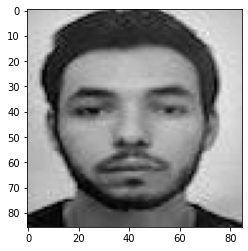

```python
pl.imshow(list_2[1,:].reshape(86,85))
```

# Classifier by gender

```python
rfc_prediction_class = rfc_clf.predict( list_2 )

print(rfc_prediction_class)
```

```
['H' 'H' 'H' 'H' 'H' 'H' 'H' 'H' 'H' 'H' 'H' 'H' 'H' 'H' 'H' 'H' 'H' 'H'
 'H' 'H']
```

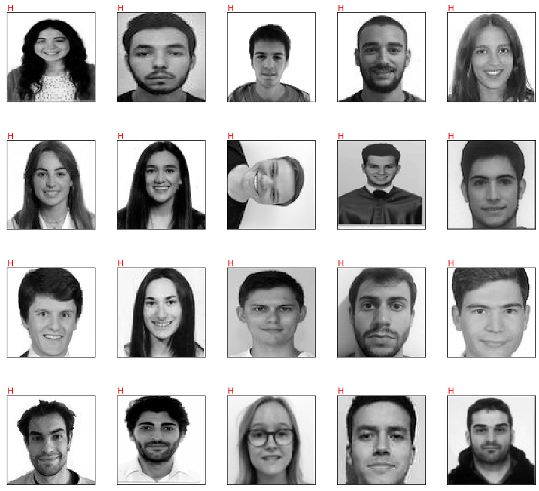

```python
from matplotlib import pyplot as plt
fig = plt.figure(figsize=(12, 11))  # figure size in inches
fig.subplots_adjust(left=0, right=1, bottom=0, top=1, hspace=0.25, wspace=0.25)


for i in range(20):
    ax = fig.add_subplot(4, 5, i + 1, xticks=[], yticks=[])
    ax.imshow(list_2[i].reshape(86,85),  interpolation='nearest')
    # label the image with the predicted gender
    ax.text(0, -2, str(rfc_prediction_class[i]), color = 'red', fontsize = 14)
```

As we can see the model seems to do a bad fit, although it classify good the (14/20) = 70 % of the dataset. It could be because the images of this new dataset are not good framing. Also there is again more mens than womens and when the model do not know what choose 'M' or 'H' is easy to choose 'H'.

- **Future work**

In future works will be interesting use a distances between eyes, mounth and nose in order to classify the gender of the dataset. I guess that the bad classification of the new dataset is because the images that are used for train the model are a bit different the face possition than the test dataset.

# 2 - Build a prediction model capable to discriminate the chamber of representatives images vs the student's class images. Provide metrics

First of all, we will join both datset and create an array with the identifyer where come each image.

```python
DATA = np.concatenate((sX, list_2))
shape(DATA), shape(sX), shape(list_2)
```

```
((368, 7310), (348, 7310), (20, 7310))
```

Create a identifier for know from where provide each image

```python
y_1 = np.repeat(1, 348)
y_2 = np.repeat(0, 20)
y_DATA = np.concatenate((y_1, y_2))
shape(y_DATA)
```

```
(368,)
```

As we did before, we going to split the data into train and test subsets in order to don't overfitting the data

```python
from sklearn.model_selection import train_test_split
x_train_c, x_test_c, y_train_c, y_test_c = train_test_split(DATA, y_DATA, random_state = 2)
```

Let's try a model that discriminate if the image come from chamber or student's class.

```python
# try the best kernel:

linear_c = svm.SVC(kernel='linear', C=1, decision_function_shape='ovo').fit( x_train_c, y_train_c )
rbf_c = svm.SVC(kernel='rbf', gamma=1, C=1, decision_function_shape='ovo').fit( x_train_c, y_train_c )
poly_c = svm.SVC(kernel='poly', degree=3, C=1, decision_function_shape='ovo').fit( x_train_c, y_train_c )
sig_c = svm.SVC(kernel='sigmoid', C=1, decision_function_shape='ovo').fit( x_train_c, y_train_c )
```

```python
linear_pred_c = linear_c.predict(x_test_c)
poly_pred_c = poly_c.predict(x_test_c)
rbf_pred_c = rbf_c.predict(x_test_c)
sig_pred_c = sig_c.predict(x_test_c)
```

```python
# retrieve the accuracy and print it for all 4 kernel functions
accuracy_lin = linear_c.score( x_test_c, y_test_c )
accuracy_poly = poly_c.score( x_test_c, y_test_c )
accuracy_rbf = rbf_c.score( x_test_c, y_test_c )
accuracy_sig = sig_c.score( x_test_c, y_test_c )

print('Kernel sigma:',round(100*accuracy_sig),'%')
print('Kernel RBF:',round(accuracy_rbf*100), '%')
print('Kernel Poly:', round(accuracy_poly*100),'%')
print('Kernel lineal:', round(accuracy_lin*100),'%')
```

```
Kernel sigma: 100 %
Kernel RBF: 95 %
Kernel Poly: 100 %
Kernel lineal: 100 %
```

# 3 - With the PCA model, being 𝑒1 and 𝑒2 the fist and second eigenvector. Reconstruct a synthetic image generated on the PCA plane 𝐼⃗ =𝜇+𝐴⋅𝑒⃗ 1+𝐵⋅𝑒⃗ 2, where A and B are two scalars. Build an interactive plot that generates the reconstructed image from A and B through two sliders.

```python
from sklearn.decomposition import PCA
from sklearn import preprocessing

sX = preprocessing.scale(X) # we scale our data N(0,1)


model_PCA_2 = PCA( n_components = 2 )
model_PCA_2.fit(X) # we use the data without scale
```

```
PCA(n_components=2)
```

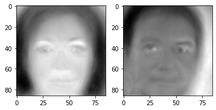

```python
# Plot the images
e_ = model_PCA_2.components_.reshape( (2, Is[0], Is[1]) )

pl.figure(figsize = (9,3))
pl.subplot(131)
pl.imshow(e_[0])

pl.subplot(132)
pl.imshow(e_[1])
```

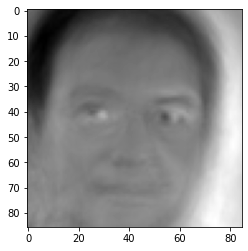

```python
A = -1
B = 100
pl.figure()
pl.imshow(A*e_[0]+B*e_[1])
```

We included @interact from the ipywidgets library. It returns the plot that we make before but with an interactive bar.

In order to use the @interacct it is create a function that plot the eigenvalues that are created before.

```python
%matplotlib inline

import math
import matplotlib.pyplot as plt
from matplotlib import figure
from ipywidgets import interact


@interact
def eign_face(A = 20, B = 20):
    pl.figure()
    plot = pl.imshow(A*e_[0]+B*e_[1])
    return(plot)
```

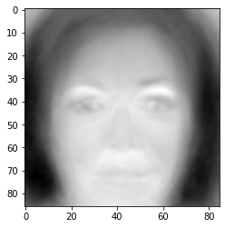

```python
eign_face(A = 100, B = -1)
```